# Reproducible Research - Course Project 1

Kevin H. Prescott

8/8/2022

# Loading and preprocessing data

### Loading required packages

```r
library(dplyr)
library(ggplot2)
library(lubridate)
```

### Loading data

We begin by loading the Activity dataset which will be used in this analysis

```r
activity_data <- read.csv("C:\\Users\\opti1039\\OneDrive - The Toronto-Dominion Bank\\Desktop\\JohnHopkinsCourse\\Data\\activity.csv", header=TRUE)
```

### Data overview and preprocessing

The raw data contains the following variables and formats :

```r
head(activity_data)
```

```
##   steps       date interval
## 1    NA 2012-10-01        0
## 2    NA 2012-10-01        5
## 3    NA 2012-10-01       10
## 4    NA 2012-10-01       15
## 5    NA 2012-10-01       20
## 6    NA 2012-10-01       25
```

We have three variables :

- Steps
- Date
- Intervals

Based on the initial sample shown above, it seems like we have missing values. Looking at summaries by variables :

```r
summary(activity_data$steps)
```

```
##    Min. 1st Qu.  Median    Mean 3rd Qu.    Max.    NA's
##    0.00    0.00    0.00   37.38   12.00  806.00    2304
```

```r
summary(activity_data$interval)
```

```
##    Min. 1st Qu.  Median    Mean 3rd Qu.    Max.
##     0.0   588.8  1177.5  1177.5  1766.2  2355.0
```

We will thus need to handle missing values in the *steps* variable and see how the *interval* one was assigned for missing values

One last thing to check before starting the analysis is the format of the *date* variable. We would want it to be in a date format so that we can easily use it in our analysis.

```r
class(activity_data$date)
```

```
## [1] "character"
```

We convert the *date* variable to a date format

```r
activity_data$date <- ymd(activity_data$date)
class(activity_data$date)
```

```
## [1] "Date"
```

# Question 1 : What is the mean total number of steps taken per day ?

### Total daily steps taken

First, we compute the total number of steps per day and store it in a dataframe

```r
sum_day_steps <- activity_data %>% filter(!is.na(steps)) %>% group_by(date) %>% summarize(total_daily_steps = sum(steps, na.rm = TRUE))
sum_day_steps
```

```
## # A tibble: 53 x 2
##    date       total_daily_steps
##    <date>                 <int>
##  1 2012-10-02               126
##  2 2012-10-03             11352
##  3 2012-10-04             12116
##  4 2012-10-05             13294
##  5 2012-10-06             15420
##  6 2012-10-07             11015
##  7 2012-10-09             12811
##  8 2012-10-10              9900
##  9 2012-10-11             10304
## 10 2012-10-12             17382
## # ... with 43 more rows
```

### Plot total daily steps taken

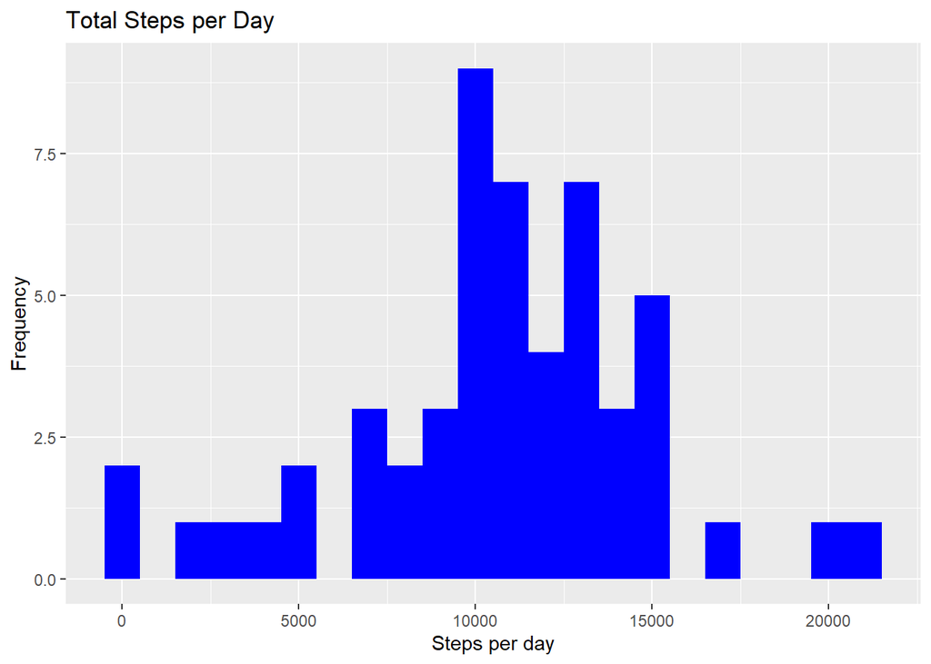

```r
sum_day_steps_plot <- ggplot(sum_day_steps, aes(total_daily_steps)) +
                      geom_histogram(fill = "blue", binwidth = 1000) +
                      labs(title = "Total Steps per Day", x = "Steps per day", y = "Frequency")
sum_day_steps_plot
```

### Mean and median of total number of steps taken per day

```r
mean_day_steps <- mean(sum_day_steps$total_daily_steps,na.rm=TRUE)
median_day_steps <- median(sum_day_steps$total_daily_steps,na.rm=TRUE)
out_stat <- as.data.frame(c(mean_day_steps,median_day_steps),row.names=c("Mean","Median"))
out_stat
```

```
##        c(mean_day_steps, median_day_steps)
## Mean                              10766.19
## Median                            10765.00
```

# Question 2 : What is the average daily activity pattern ?

### Summarize data based on average steps grouped by intervals

```r
avg_int_steps <- activity_data %>% filter(!is.na(steps)) %>% group_by(interval) %>% summarize(avg_int_steps = mean(steps))
avg_int_steps
```

```
## # A tibble: 288 x 2
##    interval avg_int_steps
##       <int>         <dbl>
##  1        0        1.72
##  2        5        0.340
##  3       10        0.132
##  4       15        0.151
##  5       20        0.0755
##  6       25        2.09
##  7       30        0.528
##  8       35        0.868
##  9       40        0
## 10       45        1.47
## # ... with 278 more rows
```

### Plot time series based on intervals and average number of steps taken

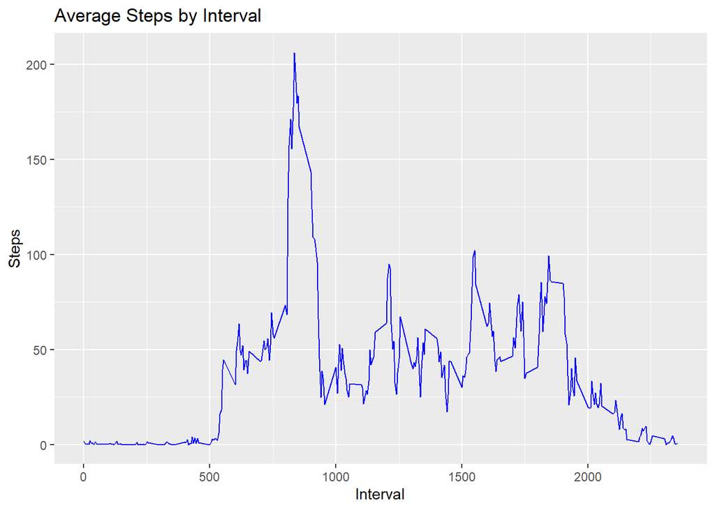

```r
avg_int_steps_plot <- ggplot(avg_int_steps, aes(interval, avg_int_steps)) +
                      geom_line(color = "blue") +
                      labs(title = "Average Steps by Interval", x = "Interval", y = "Steps")
avg_int_steps_plot
```

### Find the interval that contains the maximum number of steps on average

```r
avg_int_steps %>% filter(avg_int_steps == max(avg_int_steps))
```

```
## # A tibble: 1 x 2
##   interval avg_int_steps
##      <int>         <dbl>
## 1      835          206.
```

# Imputing missing values

In order to account for the missing values in the *steps* variable, we will replace the *N/As* by the average steps value by interval

```r
activity_data_noNA <- activity_data
na <- is.na(activity_data_noNA$steps)
avg_int <- tapply(activity_data_noNA$steps, activity_data_noNA$interval, mean, na.rm=TRUE, simplify=TRUE)
activity_data_noNA$steps[na] <- avg_int[as.character(activity_data_noNA$interval[na])]
summary(activity_data_noNA$steps)
```

```
##    Min. 1st Qu.  Median    Mean 3rd Qu.    Max.
##    0.00    0.00    0.00   37.38   27.00  806.00
```

### Total daily steps taken without NAs

Now that missing values have been replaced by the average value by interval, we repeat the summarizing an plotting steps from the first question

```r
sum_day_steps_noNA <- activity_data_noNA %>% filter(!is.na(steps)) %>% group_by(date) %>% summarize(total_daily_steps = sum(steps, na.rm = TRUE))
sum_day_steps_noNA
```

```
## # A tibble: 61 x 2
##    date       total_daily_steps
##    <date>                 <dbl>
##  1 2012-10-01            10766.
##  2 2012-10-02              126
##  3 2012-10-03            11352
##  4 2012-10-04            12116
##  5 2012-10-05            13294
##  6 2012-10-06            15420
##  7 2012-10-07            11015
##  8 2012-10-08            10766.
##  9 2012-10-09            12811
## 10 2012-10-10             9900
## # ... with 51 more rows
```

### Plot total daily steps taken without NAs

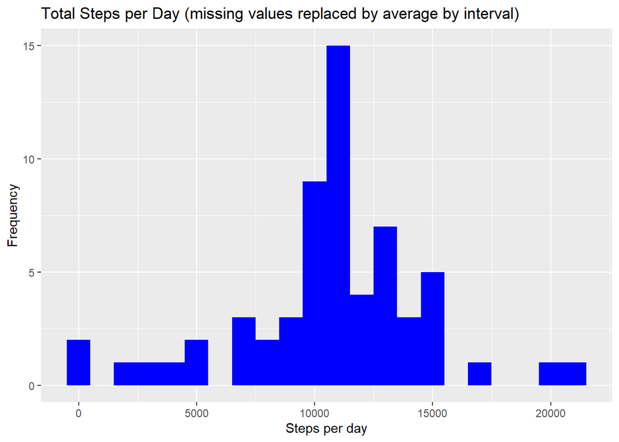

```r
sum_day_steps_noNA_plot <- ggplot(sum_day_steps_noNA, aes(total_daily_steps)) +
                      geom_histogram(fill = "blue", binwidth = 1000) +
                      labs(title = "Total Steps per Day (missing values replaced by average by interval)", x = "Steps per day", y = "Frequency")
sum_day_steps_noNA_plot
```

### Mean and median of total number of steps taken per day

```r
mean_day_steps_noNA <- mean(sum_day_steps_noNA$total_daily_steps,na.rm=TRUE)
median_day_steps_noNA <- median(sum_day_steps_noNA$total_daily_steps,na.rm=TRUE)

out_stat_noNA <- as.data.frame(c(mean_day_steps_noNA,median_day_steps_noNA),row.names=c("Mean","Median"))
out_stat_diff <- cbind(out_stat, out_stat_noNA)
names(out_stat_diff) <- c("Stat_w_NA","Stat_wo_NA")
out_stat_diff$diff <- out_stat_diff$Stat_wo_NA - out_stat_diff$Stat_w_NA
out_stat_diff
```

```
##        Stat_w_NA Stat_wo_NA     diff
## Mean    10766.19   10766.19 0.000000
## Median  10765.00   10766.19 1.188679
```

# Question 3 : Are there differences in activity patterns between weekdays and weekends

Using the dataset with missing values replaced, we start by adding a weekday/weekend indicator variable

```r
activity_data_noNA <- activity_data_noNA %>%
                      mutate(weektype = ifelse(weekdays(date)=="Saturday" | weekdays(date)=="Sunday", "weekend", "weekday"))
head(activity_data_noNA)
```

```
##       steps       date interval weektype
## 1 1.7169811 2012-10-01        0  weekday
## 2 0.3396226 2012-10-01        5  weekday
## 3 0.1320755 2012-10-01       10  weekday
## 4 0.1509434 2012-10-01       15  weekday
## 5 0.0754717 2012-10-01       20  weekday
## 6 2.0943396 2012-10-01       25  weekday
```

### Summarize data based on average steps grouped by intervals and weektype

```r
avg_int_type_steps <- activity_data_noNA %>% group_by(interval, weektype) %>% summarize(avg_steps = mean(steps))
avg_int_type_steps
```

```
## # A tibble: 576 x 3
## # Groups:   interval [288]
##    interval weektype avg_steps
##       <int> <chr>        <dbl>
##  1        0 weekday    2.25
##  2        0 weekend    0.215
##  3        5 weekday    0.445
##  4        5 weekend    0.0425
##  5       10 weekday    0.173
##  6       10 weekend    0.0165
##  7       15 weekday    0.198
##  8       15 weekend    0.0189
##  9       20 weekday    0.0990
## 10       20 weekend    0.00943
## # ... with 566 more rows
```

### Plotting results separately for weekdays and weekends

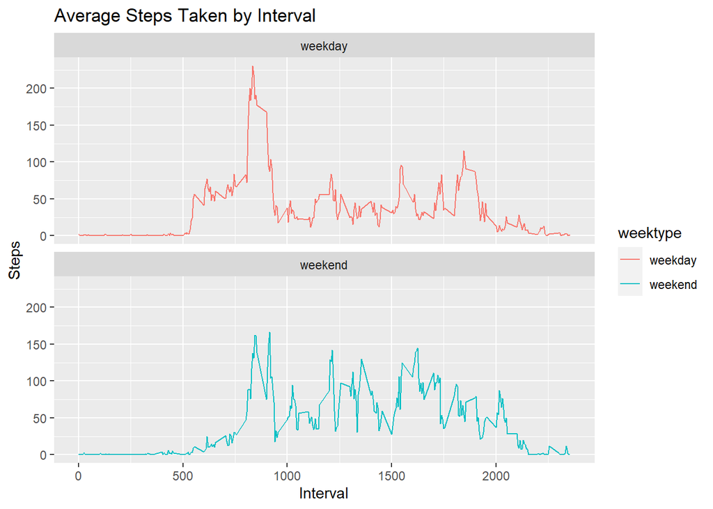

```r
wktype_int_steps_plot <-  ggplot(avg_int_type_steps, aes(interval, avg_steps, color = weektype)) +
                          geom_line() +
                          facet_wrap(~weektype, ncol = 1, nrow=2) +
                          labs(title = "Average Steps Taken by Interval", x = "Interval", y = "Steps")
wktype_int_steps_plot
```